# Tipos de filme de Emma Watson

## Exploração dos dados

Utilizando os dados de filmes que a atriz Emma Watson participou e que tenham algum valor de bilheteria construímos a análise a seguir.

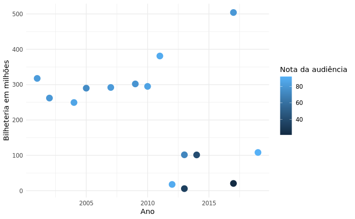

Em relação aos filmes que Emma Watson participou podemos ver que os primeiros tiveram alta bilheteria, sendo os filmes que compõem a saga Harry Poter, lançada entre 2001 e 2011. Os demais filmes tiveram menor bilheteria, com excessão de um filme lançado em 2017, A Bela e a Fera, um remake do clássico da Disney, que teve a maior bilheteria da carreira da atriz.

## Agrupamento

Relacionando os filmes que Emma Watson participou, especificamente utilizando a bilheteria e a crítica desses filmes, podemos visualizar 4 agrupamentos: os filmes com crítica variada, mas baixa bilheteria; filmes com uma boa crítica e bilheteria média; os filmes da saga harry potter; e os filmes de maior bilheteria da carreira da atriz.

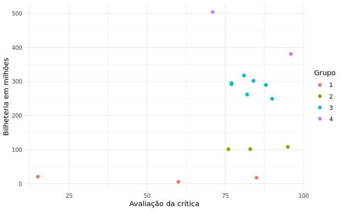

### Filmes com crítica variada, mas baixa bilheteria

| filme | bilheteria | avaliacao | ano | cluster |
| --- | --- | --- | --- | --- |
| The Bling Ring | 5.8 | 60 | 2013 | 1 |
| The Perks of Being a Wallflower | 17.7 | 85 | 2012 | 1 |
| The Circle | 20.5 | 15 | 2017 | 1 |

Esse grupo é composto pelos filmes de menor bilheteria da carreira de Emma Watson, mas com crítica variada. O filme The Perks of Being a Wallflower, um drama lançado em 2012, tem um avaliação alta. Já o filme The Circle, um thriller lançado em 2017, tem a menor avaliação entre todos os filmes.

### Filmes com uma boa crítica e bilheteria média

| filme | bilheteria | avaliacao | ano | cluster |
| --- | --- | --- | --- | --- |
| Noah | 101.2 | 76 | 2014 | 2 |
| This Is the End | 101.5 | 83 | 2013 | 2 |
| Little Women | 108.1 | 95 | 2019 | 2 |

Os filmes que tiverem uma bilheteria mediana e uma boa avaliação compõem esse grupo. Filmes como Noah, que conta uma versão do mito de Noé.

### Filmes da saga Harry Potter

| filme | bilheteria | avaliacao | ano | cluster |
| --- | --- | --- | --- | --- |
| Harry Potter and the Prisoner of Azkaban | 249.4 | 90 | 2004 | 3 |
| Harry Potter and the Chamber of Secrets | 262.0 | 82 | 2002 | 3 |
| Harry Potter and the Goblet of Fire | 290.0 | 88 | 2005 | 3 |
| Harry Potter and the Order of the Phoenix | 292.0 | 77 | 2007 | 3 |
| Harry Potter and the Deathly Hallows: Part 1 | 295.0 | 77 | 2010 | 3 |
| Harry Potter and the Half-Blood Prince | 302.0 | 84 | 2009 | 3 |
| Harry Potter and the Sorcerer's Stone | 317.6 | 81 | 2001 | 3 |

Os filmes da saga Harry Potter compõem esse agrupamento, menos o último. Todos os filmes tem bilheteria e avaliação da crítica constantes e altas, fazendo com que formem um grupo bem coeso.

### Filmes de maior bilheteria da carreira da atriz

| filme | bilheteria | avaliacao | ano | cluster |
| --- | --- | --- | --- | --- |
| Harry Potter and the Deathly Hallows: Part 2 | 381 | 96 | 2011 | 4 |
| Beauty and the Beast | 504 | 71 | 2017 | 4 |

Já o último grupo é formado pelos filmes de maior bilheteria da carreira de Emma Watson. O último filme da saga Harry Potter não está no mesmo grupo dos demais pois a sua bilheteria e crítica foram bem mais altas do que as dos demais filmes. E outro filme que compõe esse grupo é o de maior bilheteria da carreira da atriz, A Bela e a Fera.